# Description

Before looking through the analysis, take a guess. Who do you think is most likely to survive the sinking of the Titanic?

# Question

The question we will be answering during this project is what are some of the factors leading to survival in the sinking of the Titanic?  
Curiosity of this question is endless to me and helped me decide to research this topic. What if there were more women and children to survive? Or maybe more first class passengers who survived? What if more elderly passenger survived?  
Lets research the data and find out!

```python
import matplotlib.pyplot as plt
import numpy as np
import pandas as pd
import seaborn as sns
```

```python
filepath = '/Users/crenner15/Desktop/Data Science/Udacity/P2-Investigate a Dataset/Project/titanic-data.csv'
titanic_df = pd.read_csv(filepath)
```

First, I loaded the data from my laptop with the filepath then labeled the CSV as "titanic_df."

```python
titanic_df.head(n=5)
```

|  | PassengerId | Survived | Pclass | Name | Sex | Age | SibSp | Parch | Ticket | Fare | Cabin | Embarked |
| --- | --- | --- | --- | --- | --- | --- | --- | --- | --- | --- | --- | --- |
| 0 | 1 | 0 | 3 | Braund, Mr. Owen Harris | male | 22.0 | 1 | 0 | A/5 21171 | 7.2500 | NaN | S |
| 1 | 2 | 1 | 1 | Cumings, Mrs. John Bradley (Florence Briggs Th... | female | 38.0 | 1 | 0 | PC 17599 | 71.2833 | C85 | C |
| 2 | 3 | 1 | 3 | Heikkinen, Miss. Laina | female | 26.0 | 0 | 0 | STON/O2. 3101282 | 7.9250 | NaN | S |
| 3 | 4 | 1 | 1 | Futrelle, Mrs. Jacques Heath (Lily May Peel) | female | 35.0 | 1 | 0 | 113803 | 53.1000 | C123 | S |
| 4 | 5 | 0 | 3 | Allen, Mr. William Henry | male | 35.0 | 0 | 0 | 373450 | 8.0500 | NaN | S |

I decided to take a look at the first 5 rows of the data. This provided me with the columns and gave a little bit more insight on what we will be looking at in this project. See the below Data Dictionary for an explanation of the columns and data provided.

# Data Dictionary

PassengerId - Passenger ID  
survival - Survival  
pclass - Ticket class  
Name - Name of Passenger  
sex - Sex  
Age - Age in years  
sibsp - # of siblings / spouses aboard the Titanic  
parch - # of parents / children aboard the Titanic  
ticket - Ticket number  
fare - Passenger fare  
cabin - Cabin number  
embarked - Port of Embarkation, C = Cherbourg, Q = Queenstown, S = Southampton

### Key

Survival - 0 = No, 1 = Yes  
PClass - 1 = 1st, 2 = 2nd, 3 = 3rd  
embarked - C = Cherbourg, Q = Queenstown, S = Southampton

### pclass: A proxy for socio-economic status (SES)

1st = Upper  
2nd = Middle  
3rd = Lower

### Other Definitions

age: Age is fractional if less than 1. If the age is estimated, is it in the form of xx.5

sibsp: The dataset defines family relations in this way...  
Sibling = brother, sister, stepbrother, stepsister  
Spouse = husband, wife (mistresses and fiancés were ignored)

parch: The dataset defines family relations in this way...  
Parent = mother, father  
Child = daughter, son, stepdaughter, stepson  
Some children travelled only with a nanny, therefore parch=0 for them.

```python
titanic_df.info()
```

```
<class 'pandas.core.frame.DataFrame'>
RangeIndex: 891 entries, 0 to 890
Data columns (total 12 columns):
PassengerId    891 non-null int64
Survived       891 non-null int64
Pclass         891 non-null int64
Name           891 non-null object
Sex            891 non-null object
Age            714 non-null float64
SibSp          891 non-null int64
Parch          891 non-null int64
Ticket         891 non-null object
Fare           891 non-null float64
Cabin          204 non-null object
Embarked       889 non-null object
dtypes: float64(2), int64(5), object(5)
memory usage: 83.6+ KB
```

```python
with_age = titanic_df[titanic_df['Age'].notnull()]
without_age = titanic_df[titanic_df['Age'].isnull()]
```

For age, I decided the best way to find out if I should use the mean age would be to split the data into two groups, "with_age" and "without_age." I then will look at the T-Test and decide if it is reasonable to replace NaN age with the mean.

```python
from scipy.stats import ttest_ind
ttest_ind(with_age['Survived'], without_age['Survived'])
```

```
Ttest_indResult(statistic=2.7606993230995345, pvalue=0.0058865348400755626)
```

Now that we have found that there is a significant difference in the data (based on if the passenger survived), we will still implement the mean for NaN age, and make note of this for our study. We will also delete rows that will not be used and fill in the mode for Embarked NaN's in this step.

```python
titanic_df['Age'] = titanic_df['Age'].fillna(titanic_df['Age'].mean())
titanic_df['Embarked'] = titanic_df['Embarked'].fillna('S')
del titanic_df['Name']
del titanic_df['Ticket']
del titanic_df['Cabin']
```

Now let's take another look at the data to make sure the changes took effect.

```python
titanic_df.describe(include='all')
```

|  | PassengerId | Survived | Pclass | Sex | Age | SibSp | Parch | Fare | Embarked |
| --- | --- | --- | --- | --- | --- | --- | --- | --- | --- |
| count | 891.000000 | 891.000000 | 891.000000 | 891 | 891.000000 | 891.000000 | 891.000000 | 891.000000 | 891 |
| unique | NaN | NaN | NaN | 2 | NaN | NaN | NaN | NaN | 3 |
| top | NaN | NaN | NaN | male | NaN | NaN | NaN | NaN | S |
| freq | NaN | NaN | NaN | 577 | NaN | NaN | NaN | NaN | 646 |
| mean | 446.000000 | 0.383838 | 2.308642 | NaN | 29.699118 | 0.523008 | 0.381594 | 32.204208 | NaN |
| std | 257.353842 | 0.486592 | 0.836071 | NaN | 13.002015 | 1.102743 | 0.806057 | 49.693429 | NaN |
| min | 1.000000 | 0.000000 | 1.000000 | NaN | 0.420000 | 0.000000 | 0.000000 | 0.000000 | NaN |
| 25% | 223.500000 | 0.000000 | 2.000000 | NaN | 22.000000 | 0.000000 | 0.000000 | 7.910400 | NaN |
| 50% | 446.000000 | 0.000000 | 3.000000 | NaN | 29.699118 | 0.000000 | 0.000000 | 14.454200 | NaN |
| 75% | 668.500000 | 1.000000 | 3.000000 | NaN | 35.000000 | 1.000000 | 0.000000 | 31.000000 | NaN |
| max | 891.000000 | 1.000000 | 3.000000 | NaN | 80.000000 | 8.000000 | 6.000000 | 512.329200 | NaN |

I wanted to know a bit more about the dat and survival rates, so I created graphs of data to compare specific categoties on survival rate. First, I grouped the age into four specific categories: Child, Adult, Mid-Age, and Elderly

```python
def age_grouping(age):
    if age >= 65:
        return 'Elderly'
    elif age >= 40:
        return 'Mid-Age'
    elif age >= 18:
        return 'Adult'
    else:
        return 'Child'

titanic_df['AgeGr'] = titanic_df['Age'].apply(age_grouping)
```

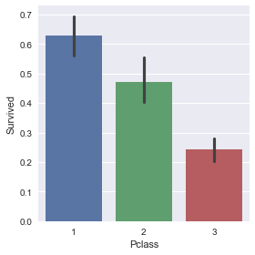

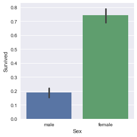

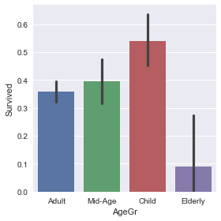

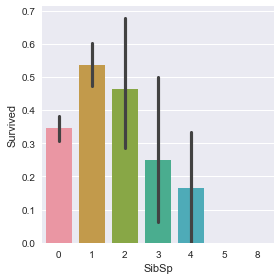

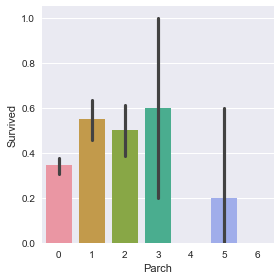

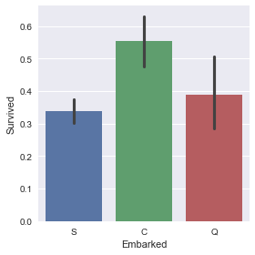

```python
%pylab inline
sns.factorplot('Pclass','Survived', data = titanic_df, kind = 'bar')
sns.factorplot('Sex','Survived', data = titanic_df, kind = 'bar')
sns.factorplot('AgeGr','Survived', data = titanic_df, kind = 'bar')
sns.factorplot('SibSp','Survived', data = titanic_df, kind = 'bar')
sns.factorplot('Parch','Survived', data = titanic_df, kind = 'bar')
sns.factorplot('Embarked','Survived', data = titanic_df, kind = 'bar')
```

The graphs help claify a lot of information in the data. I am going to go through each graph and communicate the most interesting facts that I have found from the data.

- **Passenger Class** - This information is very interesting to say the least. First class passengers were more likely to survive compared to second class passengers, and second class passengers were more likely to survive than third class. With this downward trend it is easy to say that the higher your class on the ship, the more likely you were to survive.
- **Sex** - The sex of the passengers who survived was an expected outcome. As most people who have seen the movie titanic, they know that women and children were the first on the life boats.
- **Age Group** - This was somewhat an unexpected outcome for the adult category. Noting that we filled the mean age into blank cells earlier in this experiment, I had expected this to be one of the highest groups. Seeing that this is the second lowest category, it means that adults between the age of 18 and 39 were less likely to survive than the middle aged passengers between the age of 40 and 64.
- **Embarked** - I thought it was a fun fact that the passengers who embarked from Cherbourg were more likely to survive than other passengers. It may be likely that these passengers were mainly women and children or more passengers embarked from this location.
- **Siblings/Spouse & Parent/Children** - These charts were less informative than expected, other than the fact that you would be most likely to survive with 3 parents/children than you would any other amount of children.

# Conclusion

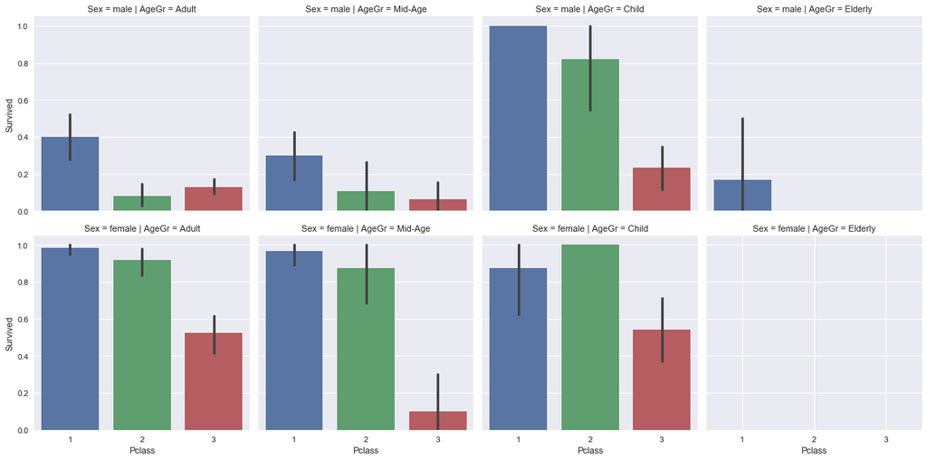

```python
sns.factorplot(x='Pclass', y='Survived', col='AgeGr', row='Sex', data=titanic_df, kind="bar")
```

# Limitations

While looking throught the results of the data, I did notice one major limitation of the data I was working with, and that is the age section. Without the propper age, it is tough to compare the age of the passenger to the survival rate. While looking at the age distribution notice that there is a large spike in the age section, which is due to adding the mean age to passengers without an age in the data.

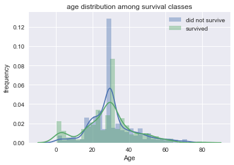

```python
sns.distplot(titanic_df.loc[(titanic_df['Survived']==0) & (~titanic_df['Age'].isnull()),'Age'], bins=30)
sns.distplot(titanic_df.loc[(titanic_df['Survived']==1) & (~titanic_df['Age'].isnull()),'Age'], bins=30)
plt.title('age distribution among survival classes')
plt.ylabel('frequency')
plt.legend(['did not survive', 'survived']);
```